# 11.Sınav Rehberi

## 11.1 Sınav Ekranı

1. Online sınav olabilmek için kullanıcı adınızı ve şifrenizi kullanarak Pynar Editöründe oturum açmış olmanız gerekmektedir. [**Buraya**](http://www.pynar.org/help/Yardim_Bolum3.html) tıklayarak Pynar Editöründe nasıl oturum açacağınızı detaylı bir şekilde öğrenebilirsiniz.
2. Oturum açtıktan sonra sizin için tanımlanmış kaç adet sınav olduğunu aşağıdaki gibi görebilirsiniz.

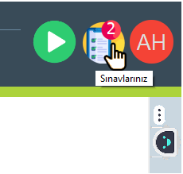

3. Sınavlarınız butonuna tıkladığınızda tanımlanmış sınavların listesini görürsünüz.

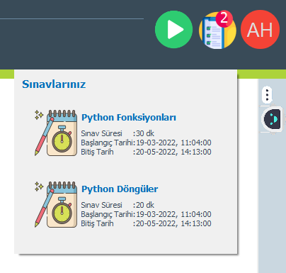

## 11.2 Sınav Başlatma

1. Sınava tıkladığınızda sınavı başlatmak için gereken ekrana yönlendirilirsiniz.

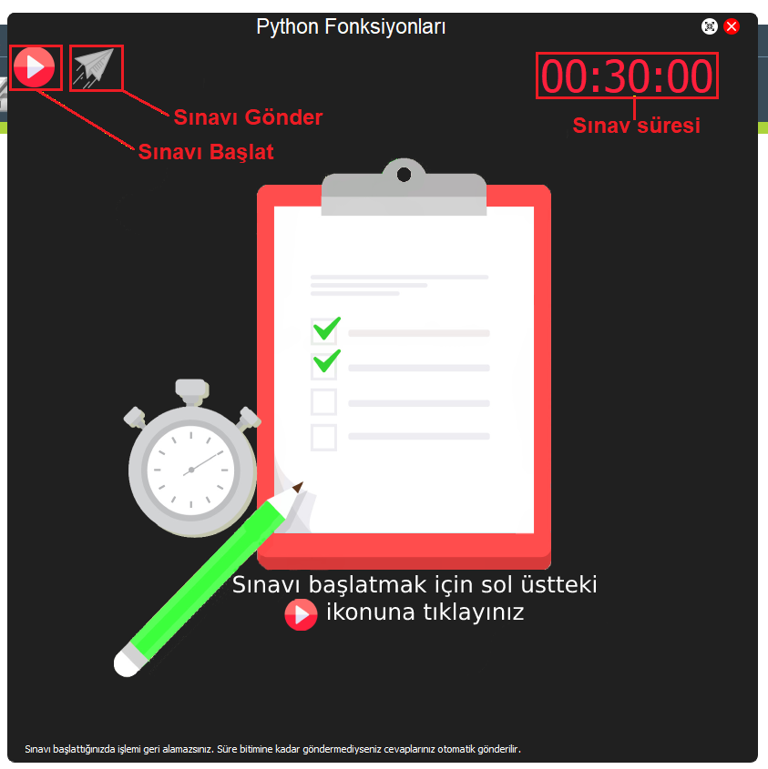

*2. Sınavı başlatmadan önce sadece 1 tane boş bir kod editörü açmanız gerekmektedir.*

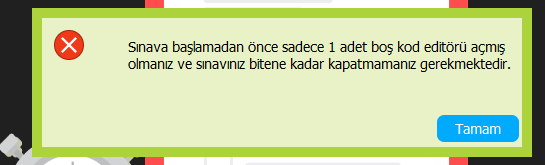

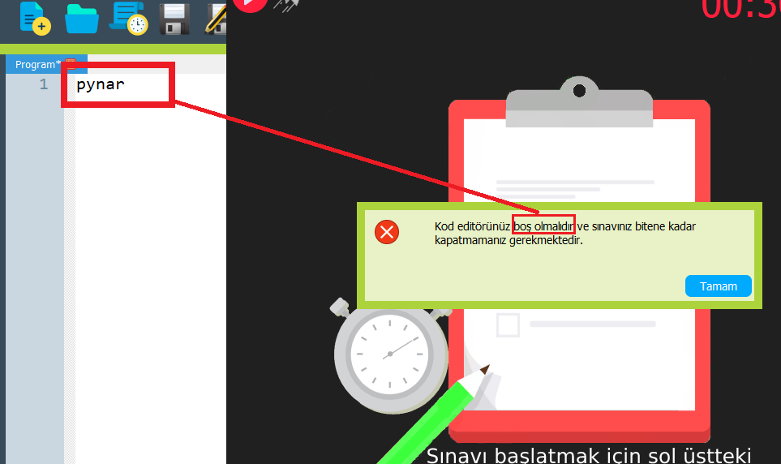

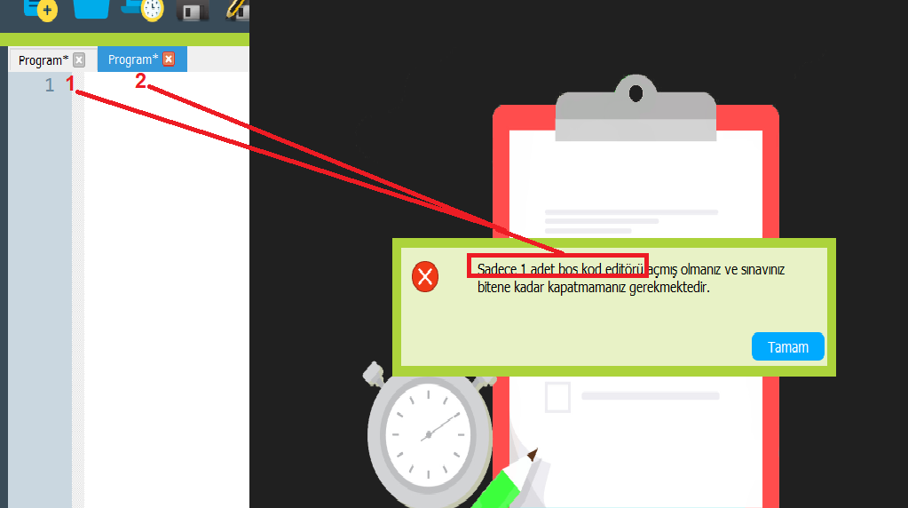

*3. Sınavı başlatmadan önce Ayarlar penceresi altından Pynar Editörün sınav verilerinizi kaydetmesine izin veriniz.(Sınavın başlaması için zorunludur.)*

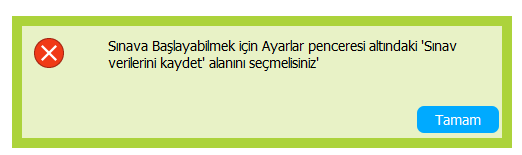

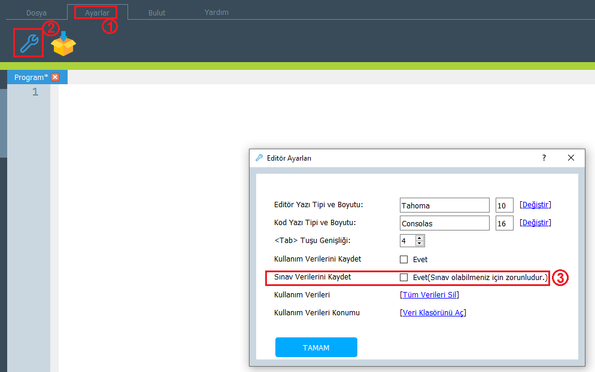

4. Sınavı başlat düğmesine tıklayınız ve gelen ekranda evet seçeneğini seçiniz.

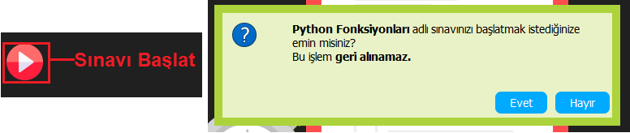

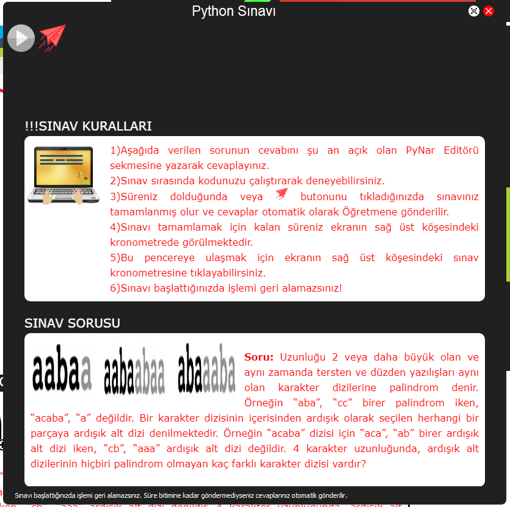

5. Açık olan kod editörüne sınav sorunuzun cevabını kodlayınız. Sınavınız tamamlandığında kodlarınız otomatik olarak gönderilecektir.
6. Öğretmeninizin ilgili sınava ait eklediği resimleri resimlere tıklayarak büyütebilirsiniz

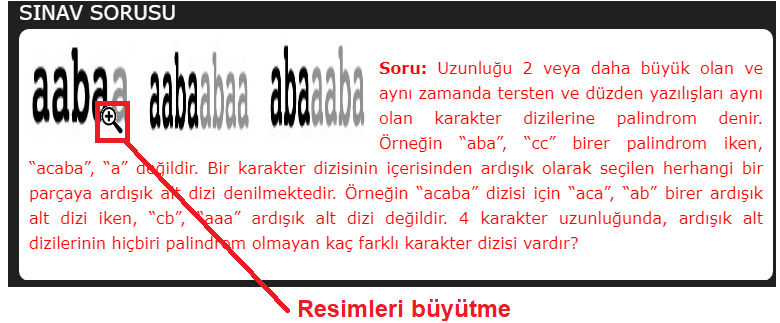

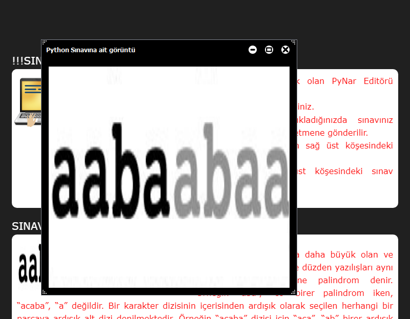

7. Sınav kronometresi sınavınızın otomatik olarak tamamlanması için kalan süreyi gösterir. Başka sekmelere geçebilirsiniz ya da Pynar editörü minimize edebilirsiniz ama kronomtre ekranda sabittir, kapatılamaz. Mouse ile sürükleyerek ekranda sizi rahatsız etmeyecek bir konuma taşıyabilirsiniz.

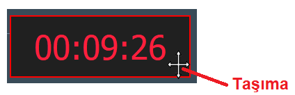

## 11.3 Sınav Bitirme

1. Sınavı sonlandırmak için Sınavı Gönder düğmesine yada ekranı kapatma düğmesine tıklayınız.

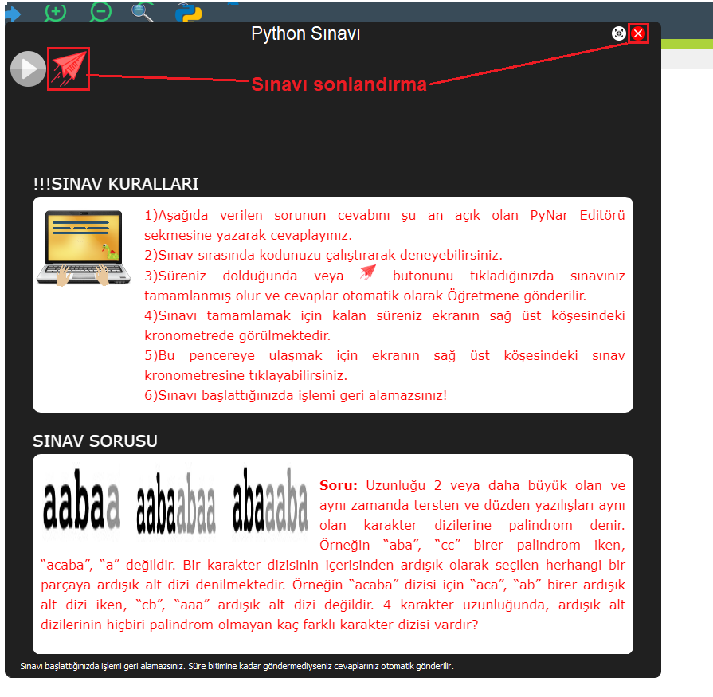

2. Gelen ekranda evet seçeneğini seçiniz.

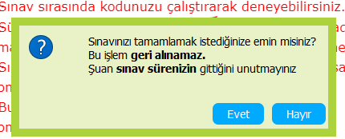

3. Sınavınız başarı ile tamamlanmıştır ve kodlarınız öğretmeninize gönderilmiştir.

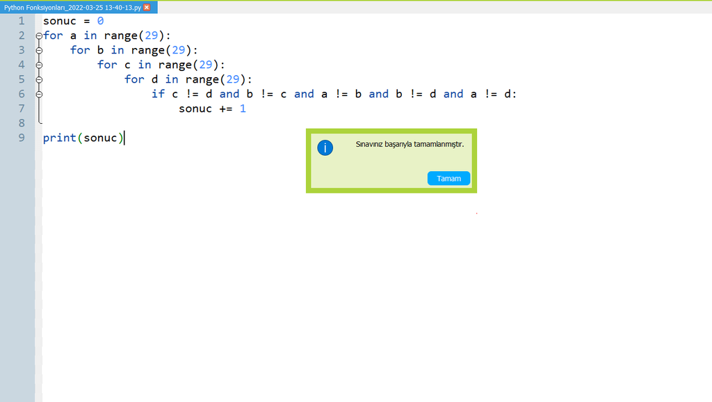